# App Rating Prediction

```python
#calling all the libraries
import pandas as pd
import numpy as np
import matplotlib.pyplot as plt
import seaborn as sns
%matplotlib inline
```

1. Loading & Checking the Data

```python
#loading data
df=pd.read_csv(r"C:\Users\USER\Downloads\App Rating Prediction @ Python\googleplaystore.csv")
df.head()
```

|  | App | Category | Rating | Reviews | Size | Installs | Type | Price | Content Rating | Genres | Last Updated | Current Ver | Android Ver |
| --- | --- | --- | --- | --- | --- | --- | --- | --- | --- | --- | --- | --- | --- |
| 0 | Photo Editor & Candy Camera & Grid & ScrapBook | ART_AND_DESIGN | 4.1 | 159 | 19M | 10,000+ | Free | 0 | Everyone | Art & Design | January 7, 2018 | 1.0.0 | 4.0.3 and up |
| 1 | Coloring book moana | ART_AND_DESIGN | 3.9 | 967 | 14M | 500,000+ | Free | 0 | Everyone | Art & Design;Pretend Play | January 15, 2018 | 2.0.0 | 4.0.3 and up |
| 2 | U Launcher Lite – FREE Live Cool Themes, Hide ... | ART_AND_DESIGN | 4.7 | 87510 | 8.7M | 5,000,000+ | Free | 0 | Everyone | Art & Design | August 1, 2018 | 1.2.4 | 4.0.3 and up |
| 3 | Sketch - Draw & Paint | ART_AND_DESIGN | 4.5 | 215644 | 25M | 50,000,000+ | Free | 0 | Teen | Art & Design | June 8, 2018 | Varies with device | 4.2 and up |
| 4 | Pixel Draw - Number Art Coloring Book | ART_AND_DESIGN | 4.3 | 967 | 2.8M | 100,000+ | Free | 0 | Everyone | Art & Design;Creativity | June 20, 2018 | 1.1 | 4.4 and up |

```python
#to find out the no. of rows & columns
df.shape
```

```
(10841, 13)
```

```python
#to find the not null values & data type for each column
df.info()
```

```
<class 'pandas.core.frame.DataFrame'>
RangeIndex: 10841 entries, 0 to 10840
Data columns (total 13 columns):
 #   Column          Non-Null Count  Dtype
---  ------          --------------  -----
 0   App             10841 non-null  object
 1   Category        10841 non-null  object
 2   Rating          9367 non-null   float64
 3   Reviews         10841 non-null  object
 4   Size            10841 non-null  object
 5   Installs        10841 non-null  object
 6   Type            10840 non-null  object
 7   Price           10841 non-null  object
 8   Content Rating  10840 non-null  object
 9   Genres          10841 non-null  object
 10  Last Updated    10841 non-null  object
 11  Current Ver     10833 non-null  object
 12  Android Ver     10838 non-null  object
dtypes: float64(1), object(12)
memory usage: 1.1+ MB
```

```python
#description of the data in the DataFrame
df.describe()
```

|  | Rating |
| --- | --- |
| count | 9367.000000 |
| mean | 4.193338 |
| std | 0.537431 |
| min | 1.000000 |
| 25% | 4.000000 |
| 50% | 4.300000 |
| 75% | 4.500000 |
| max | 19.000000 |

1. Checking for Null Values: Identifying and counting null values in each column.

```python
# Checking for null values
null_counts = df.isnull().sum()
print(null_counts)
```

```
App                  0
Category             0
Rating            1474
Reviews              0
Size                 0
Installs             0
Type                 1
Price                0
Content Rating       1
Genres               0
Last Updated         0
Current Ver          8
Android Ver          3
dtype: int64
```

1. Dropping Records with Null Values: Remove records with null values in any column.

```python
# Droping records with null values
df.dropna(inplace=True)
null_counts = df.isnull().sum()
print(null_counts)
```

```
App               0
Category          0
Rating            0
Reviews           0
Size              0
Installs          0
Type              0
Price             0
Content Rating    0
Genres            0
Last Updated      0
Current Ver       0
Android Ver       0
dtype: int64
```

1. Fixing Variable Types and Formatting:

```python
# Size column: Convert to numeric
df['Size'] = df['Size'].apply(lambda x: str(x).replace('M', '') if 'M' in str(x) else x)
df['Size'] = df['Size'].apply(lambda x: str(x).replace('Varies with device', 'nan') if 'Varies with device' in str(x) else x)

# Scaling all the values to Millions format (means that 19.0 => 19x10^6 => 19M)
df['Size'] = df['Size'].apply(lambda x: float(str(x).replace('k', ''))/1000 if 'k' in str(x) else x)
df['Size'] = df['Size'].apply(lambda x : float(x))
df = df[pd.notnull(df['Size'])]
df['Size'].dtype
```

```
dtype('float64')
```

```python
# Reviews column: Convert to numeric
df['Reviews'] = pd.to_numeric(df['Reviews'], errors='coerce')
df['Reviews'].dtype
```

```
dtype('int64')
```

```python
# Installs column: Convert to integer
df['Installs'] = df['Installs'].apply (lambda x: str(x).replace('+','') if '+' in str(x) else x)
df['Installs'] = df['Installs'].apply(lambda x: str(x).replace(',', '') if ',' in str(x) else x)
df['Installs'] = df['Installs'].apply(lambda x: int (x))
df['Installs'].dtype
```

```
dtype('int64')
```

```python
# Price column: Convert to numeric
df['Price'] = df['Price'].apply(lambda x: float(x.strip('$')))
df['Price'].dtype
```

```
dtype('float64')
```

1. Sanity Checking

```python
# Checking rows with rating outside the range [1, 5]
df['Rating'].unique()
df[df['Rating']>5].shape[0]
```

```
0
```

```python
# checking rows where reviews are greater than installs
df[df['Reviews']>df['Installs']].shape[0]
```

```
6
```

```python
# droping rows where reviews are greater than installs
df.drop(df[df['Reviews']>df['Installs']].index, inplace = True)
```

```python
# For free apps, price should be 0
df[(df['Type']=='free')& (df['Price'] ==0)].shape[0]
```

```
0
```

1. Performing Univariate Analysis:

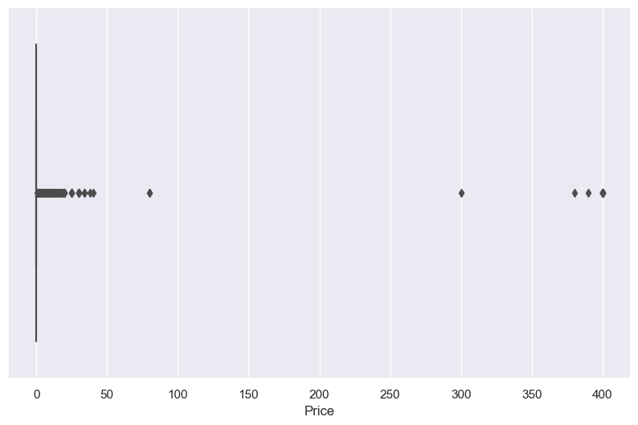

```python
# Boxplot for Price
sns.set(rc={'figure.figsize':(10,6)})
sns.boxplot(x= 'Price',data= df)
```

So there are some outliers in the Price column, which means there are some apps whose price is more than usual apps on the Googleplaystore.

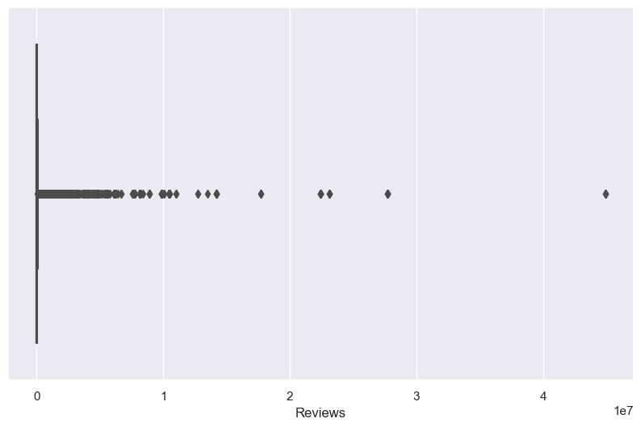

```python
# Boxplot for Reviews
sns.boxplot(x ='Reviews', data =df)
```

So there are some apps that have a very high number of Reviews.

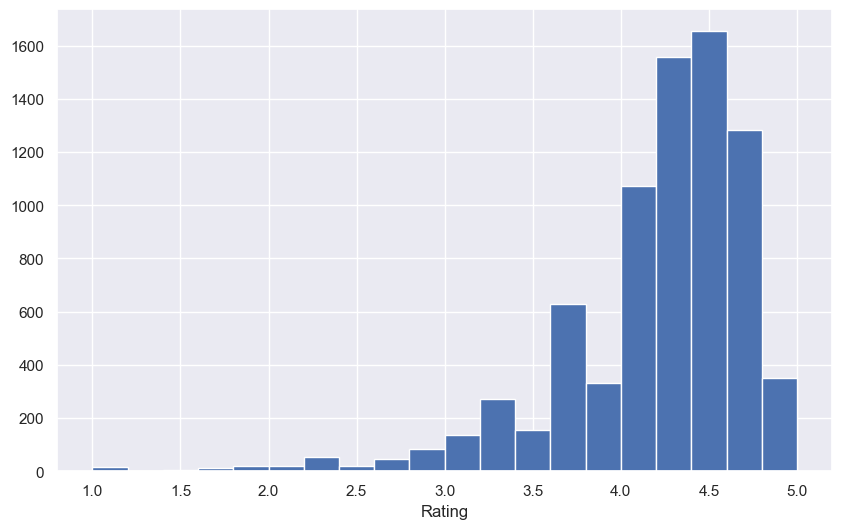

```python
# Histogram for Rating
plt.hist(df['Rating'], bins=20)
plt.xlabel('Rating')
plt.show()
```

Most the ratings are between 4 to 5. A large no. of apps have a rating of 4.5.

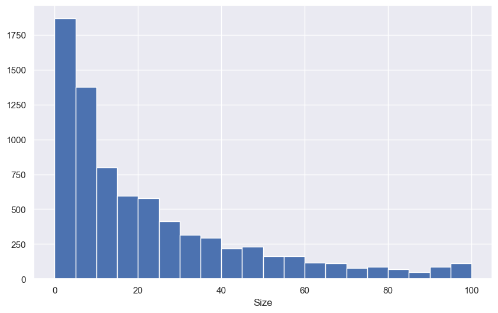

```python
# Histogram for Size
plt.hist(df['Size'], bins=20)
plt.xlabel('Size')
plt.show()
```

```python
Most of the apps takes very less memory space to install.
```

1. Outlier Treatment

```python
# Price outliers: Checking if price of $200 and above for an application
df[df['Price']>200].index.shape[0]
```

```
15
```

```python
#Dropping these apps as they are Junk apps
df.drop(df[df['Price']>200].index, inplace= True)
```

```python
# Reviews outliers: Checking records having more than 2 million reviews
df.loc[df['Reviews']>2000000].shape[0]
```

```
219
```

```python
#Dropping these apps as they these will skew the analysis
df.drop(df[df['Reviews']>2000000].index, inplace= True)
```

```python
# Installs outliers: Finding out the different percentiles
percentiles = df['Installs'].quantile([0.1, 0.25, 0.5, 0.7, 0.9, 0.95, 0.99])
print(percentiles)
```

```
0.10        1000.0
0.25       10000.0
0.50      100000.0
0.70     1000000.0
0.90    10000000.0
0.95    10000000.0
0.99    50000000.0
Name: Installs, dtype: float64
```

```python
#dropping the value more than the cutoff(threshold -95th percentile)
df.drop(df[df['Installs']>10000000].index, inplace= True)
```

1. Bivariate Analysis

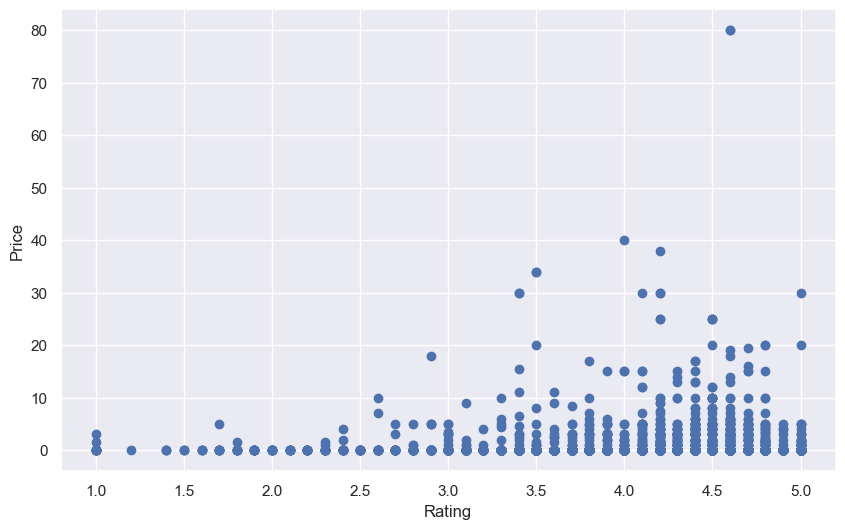

```python
# Scatterplot/jointplot for Rating vs. Price
plt.scatter(df['Rating'], df['Price'])
plt.xlabel('Rating')
plt.ylabel('Price')
plt.show()
```